# ggplot

But wait, there are 234 rows and I don’t think I see 234 points. We should jitter.

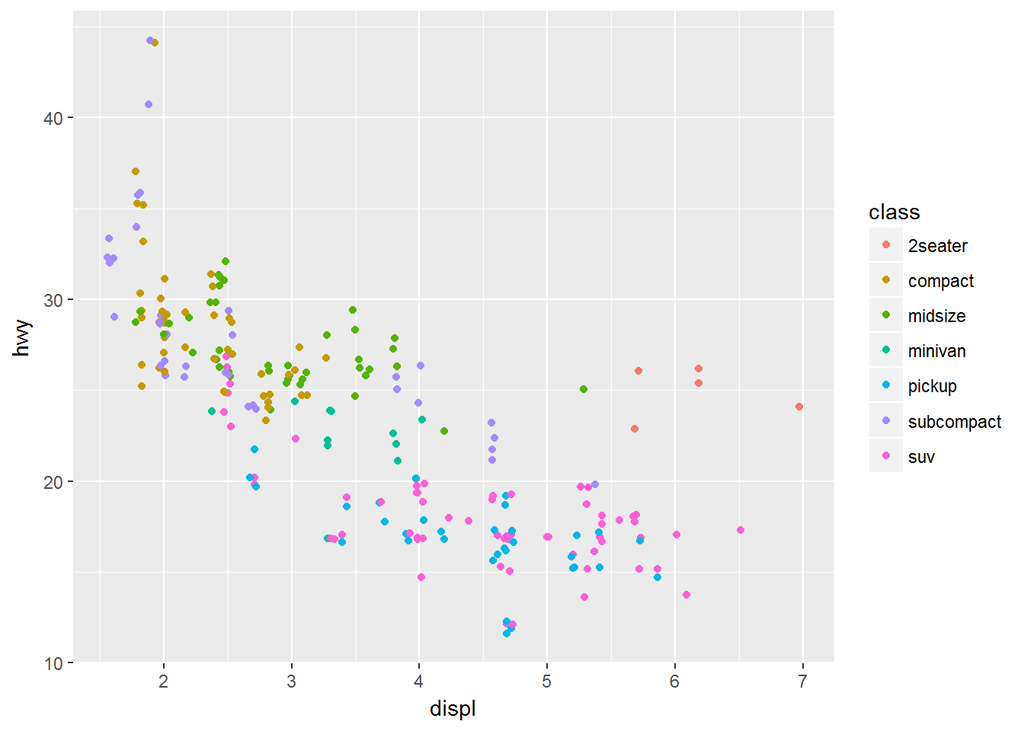

```r
ggplot(mpg, aes(displ, hwy, color=class)) + geom_jitter()
```

```r
ggplot(mpg, aes(displ, hwy, color=class)) + geom_jitter(width=0,height=0)
```

[output not shown]

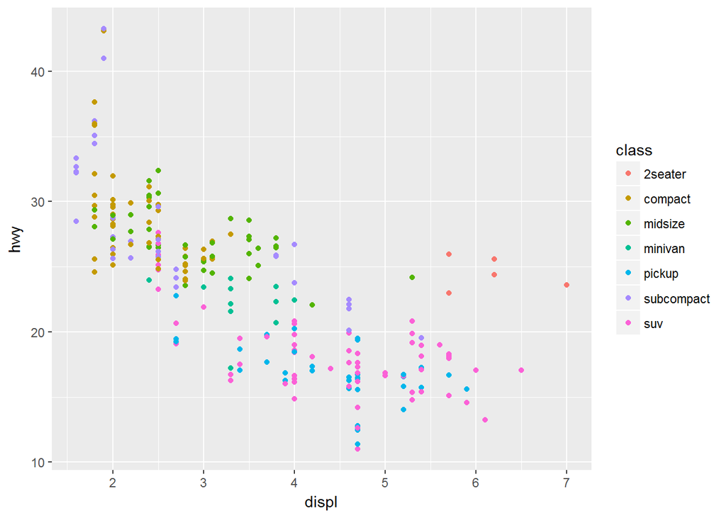

```r
ggplot(mpg, aes(displ, hwy, color=class)) + geom_jitter(width=0,height=1)
```

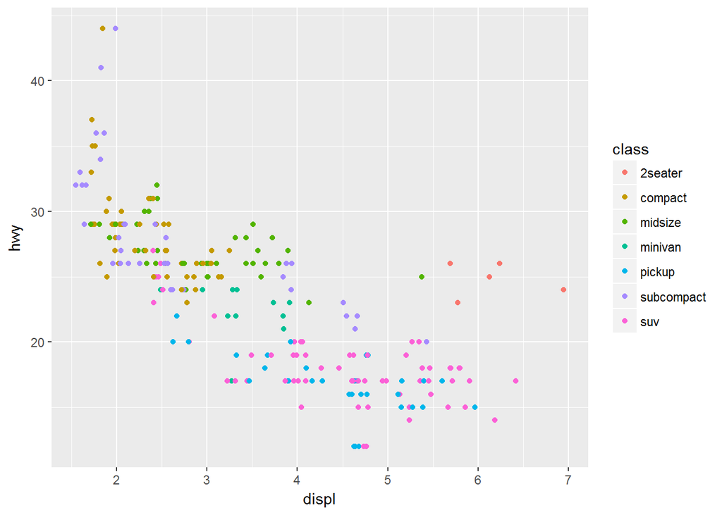

```r
ggplot(mpg, aes(displ, hwy, color=class)) + geom_jitter(width=.1,height=0)
```

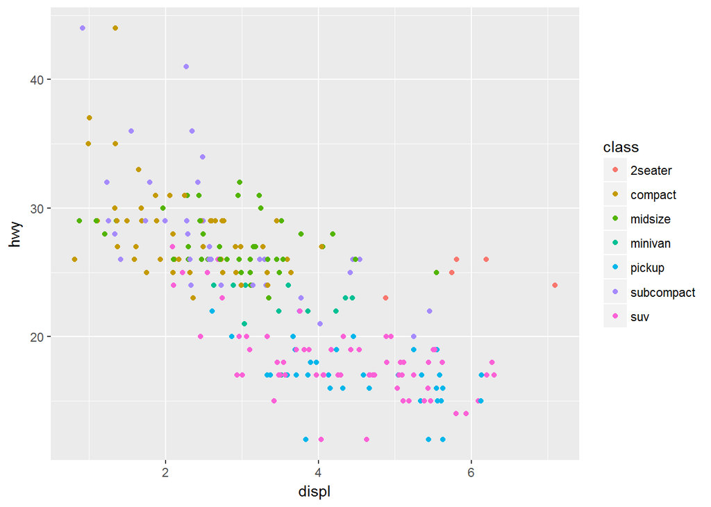

```r
ggplot(mpg, aes(displ, hwy, color=class)) + geom_jitter(width=1,height=0)
```

## How does jittering work?

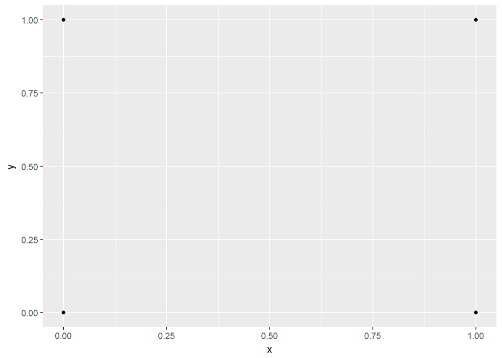

```r
reps <- 100
d <- d0 <- data.frame(x=rep(c(0,0,1,1),reps),y=rep(c(0,1,0,1),reps))
ggplot(d, aes(x,y)) + geom_point()
```

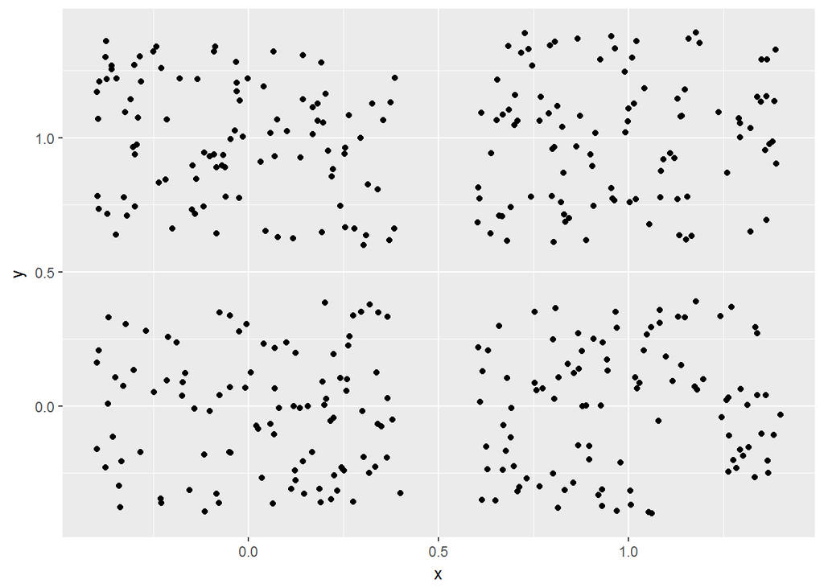

```r
ggplot(d, aes(x,y)) + geom_jitter()
```

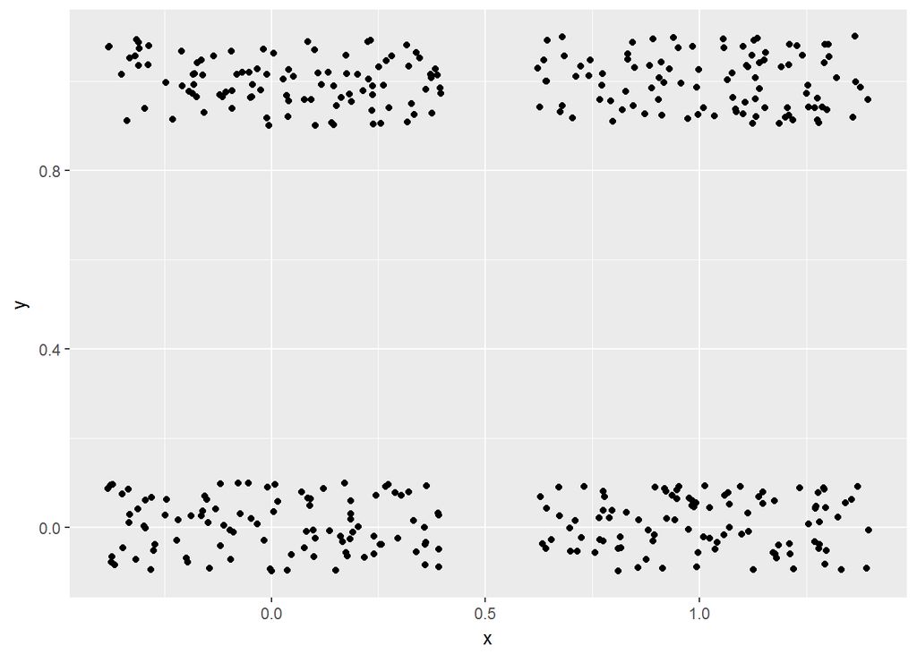

```r
ggplot(d, aes(x,y)) + geom_jitter(height=0.1)
```

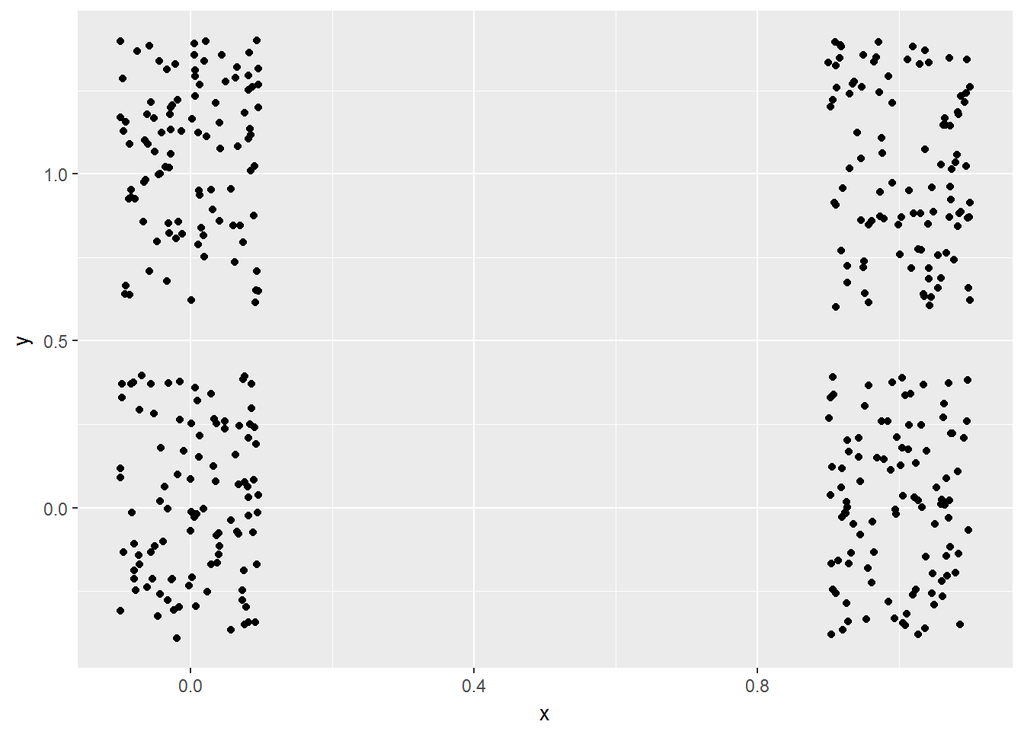

```r
ggplot(d, aes(x,y)) + geom_jitter(width=0.1)
```

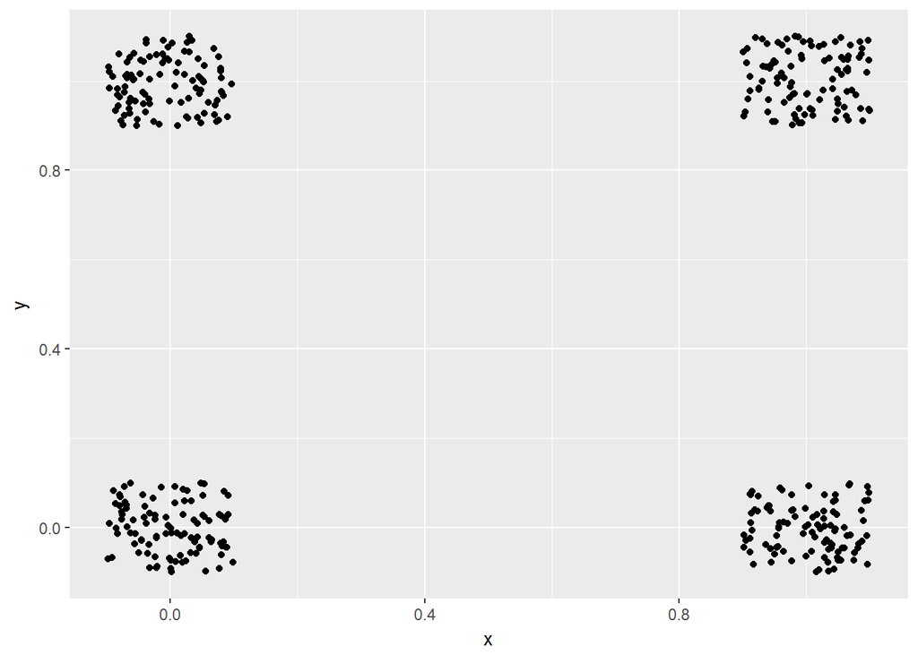

```r
ggplot(d, aes(x,y)) + geom_jitter(width=0.1, height = 0.1)
```

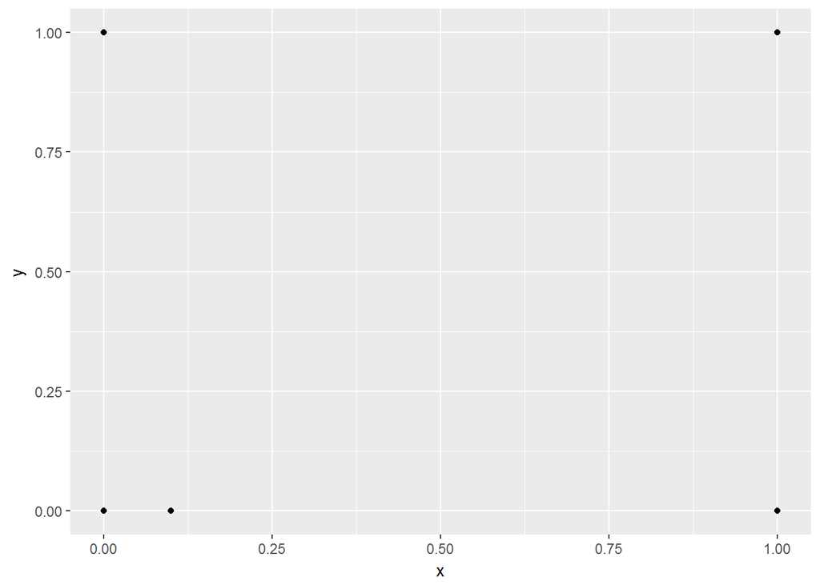

```r
d <- rbind(d0, data.frame(x=.1,y=0))
ggplot(d, aes(x,y)) + geom_point()
```

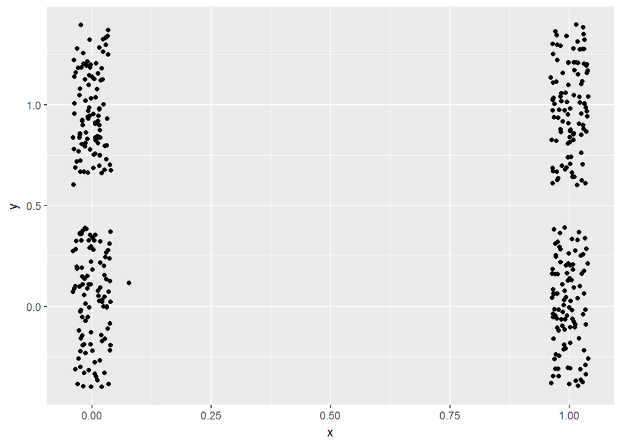

```r
ggplot(d, aes(x,y)) + geom_jitter()
```

## Facetting

To make separate plots of subsets determined by values of a variable.

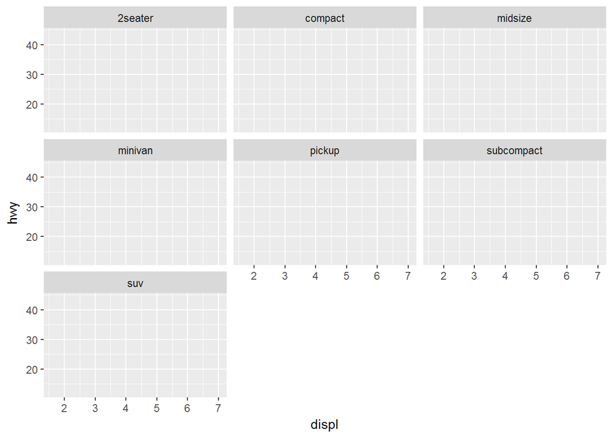

```r
p <- ggplot(mpg, aes(displ, hwy))
p + facet_wrap(~class)
```

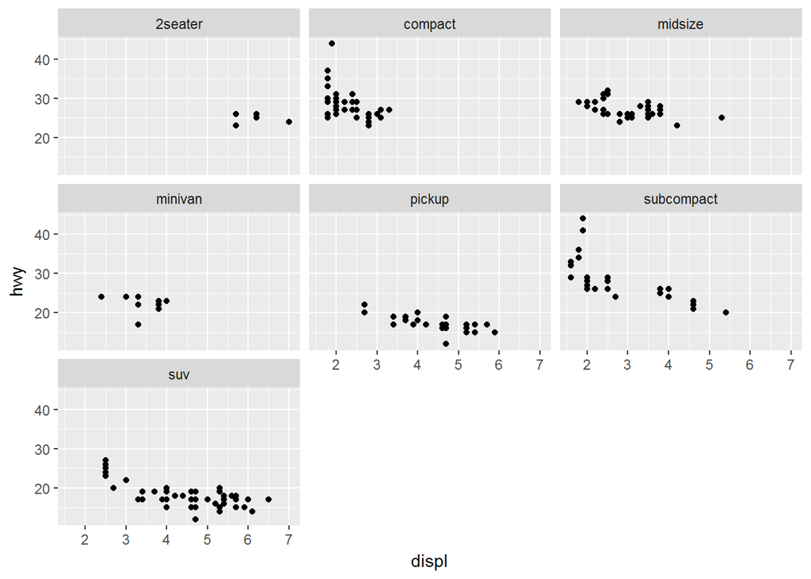

```r
p + facet_wrap(~class) + geom_point()
```

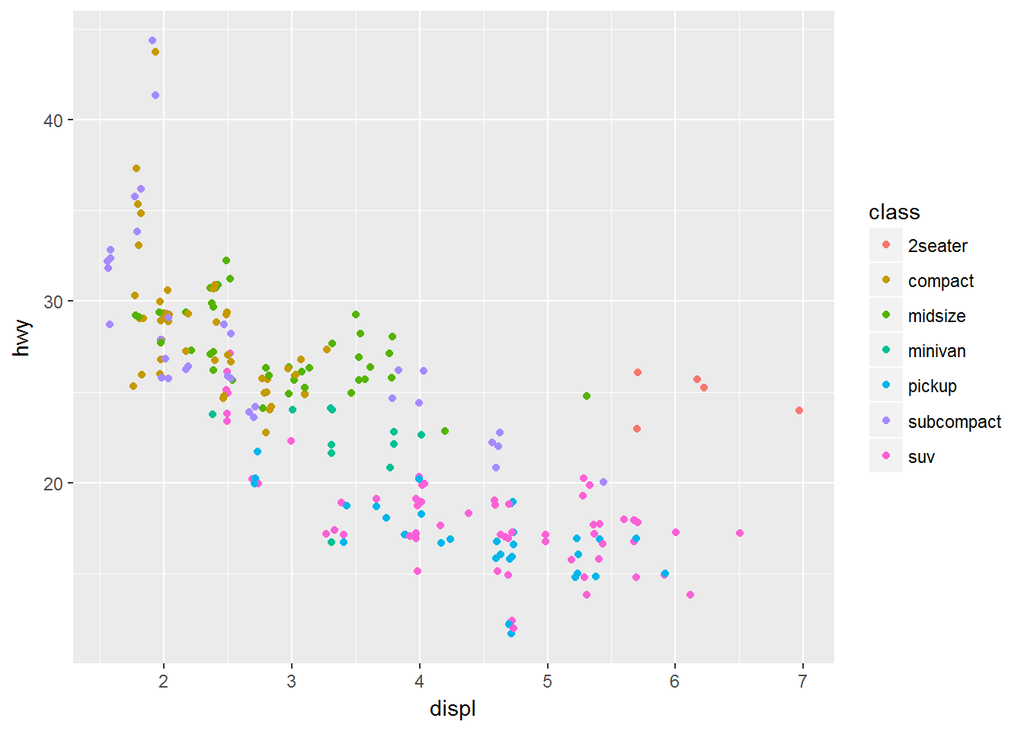

```r
# compare to using an aesthetic:
p + geom_jitter(aes(color=class))
```

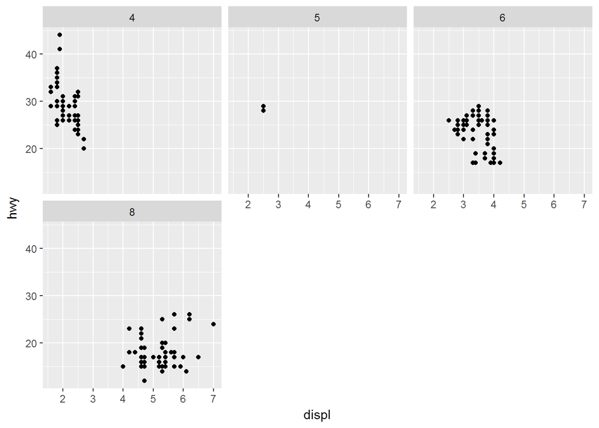

```r
# Can specify the number of columns:
p + facet_wrap(~cyl, ncol = 3) + geom_point()
```

Scales free vs constrained: by default the scales on the axes are consistent with each other across the facets. But this can be controlled, and you can “free” the x and/or y scales:

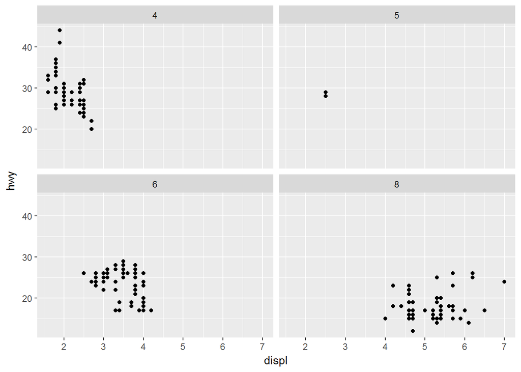

```r
p + facet_wrap(~cyl) + geom_point()
```

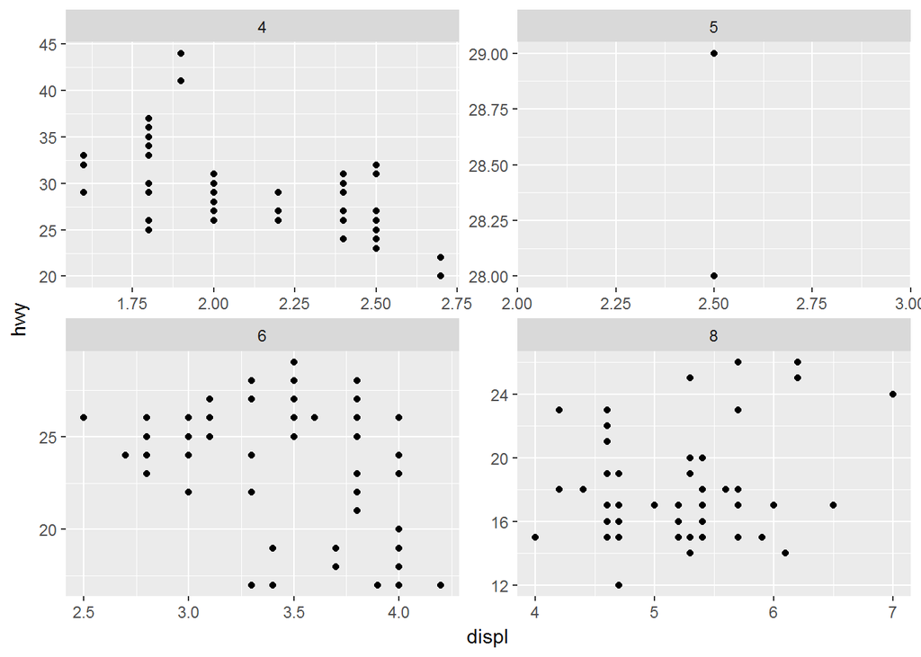

```r
p + facet_wrap(~cyl, scales = "free") + geom_point()
```

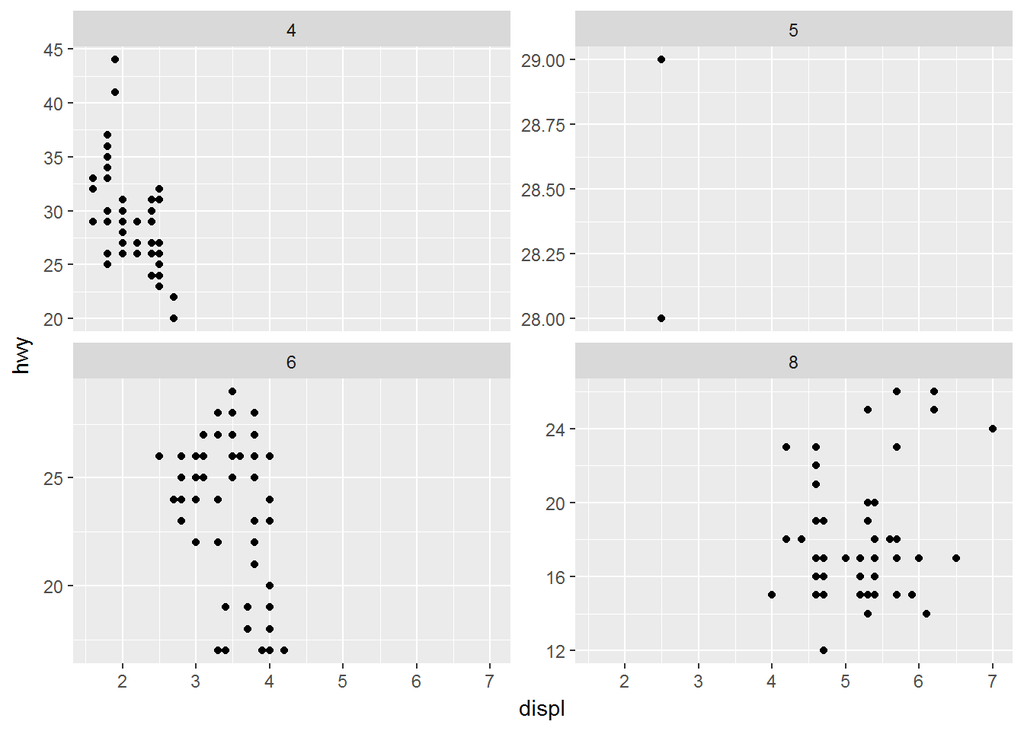

```r
p + facet_wrap(~cyl, scales = "free_y") + geom_point()
```

## More Geoms

Smoothing, including linear and also nonlinear regression using “loess” (for “locally weighted regression”):

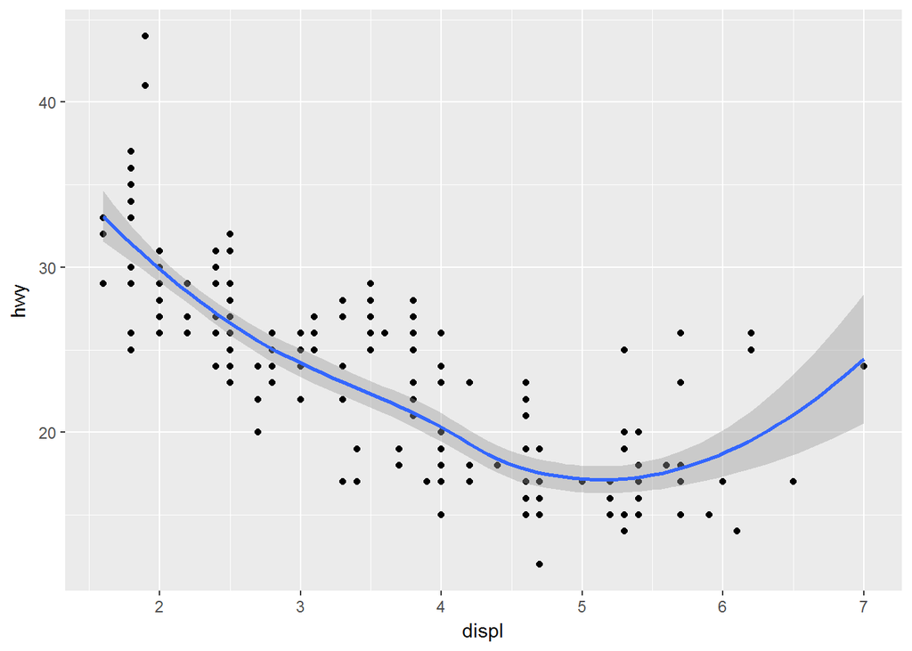

```r
p + geom_point() + geom_smooth()
```

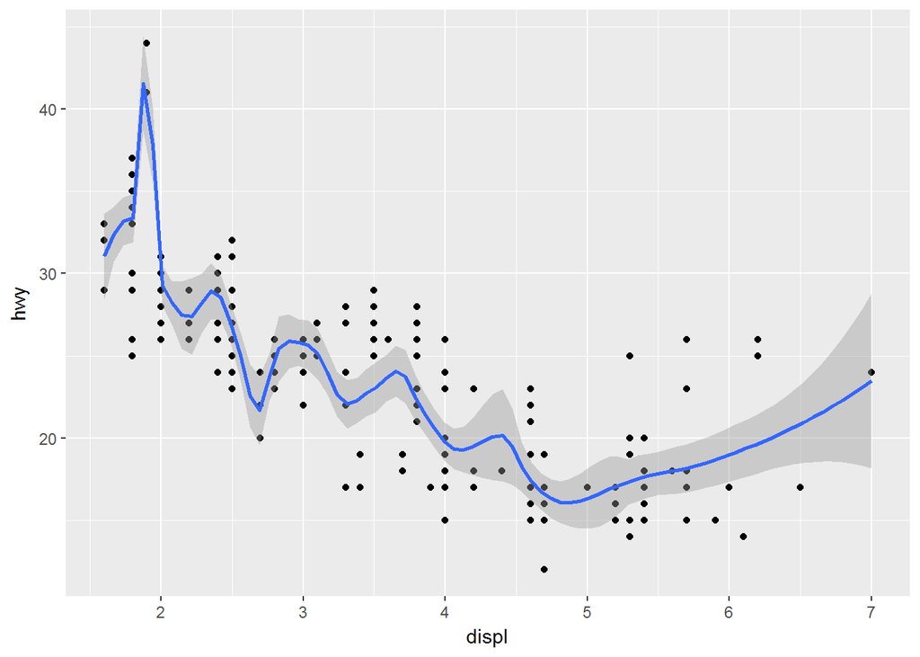

```r
# Default is "loess" method. Smoothing is controlled by "span" parameter, the larger the smoother.
p + geom_point() + geom_smooth(span=.2)
```

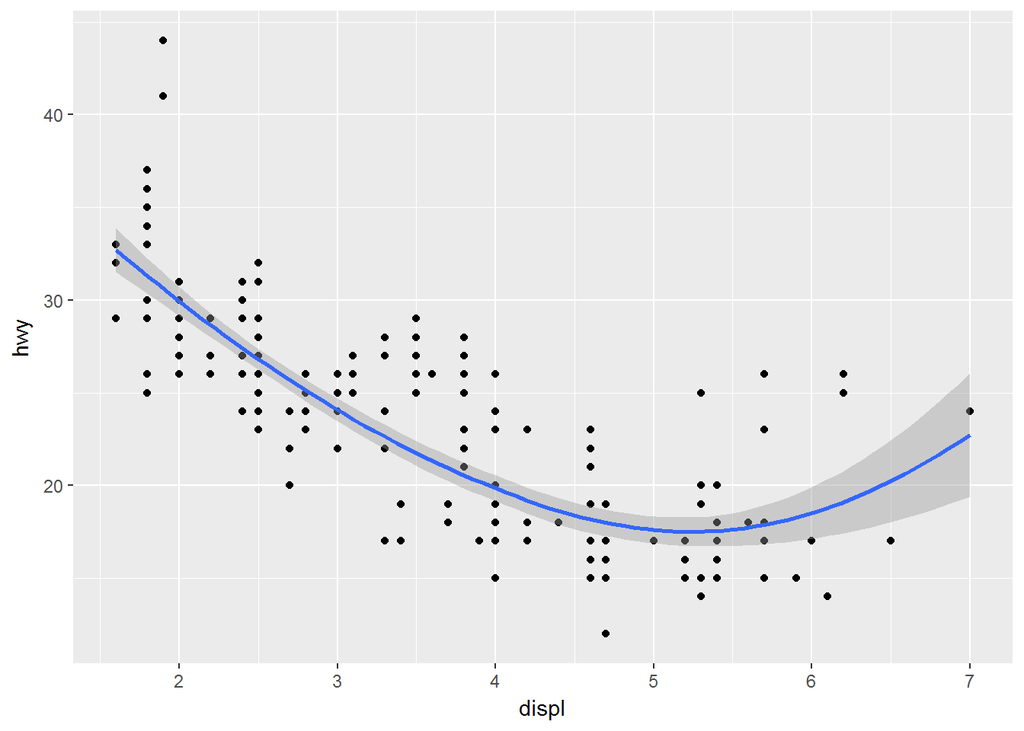

```r
p + geom_point() + geom_smooth(span=1)
```

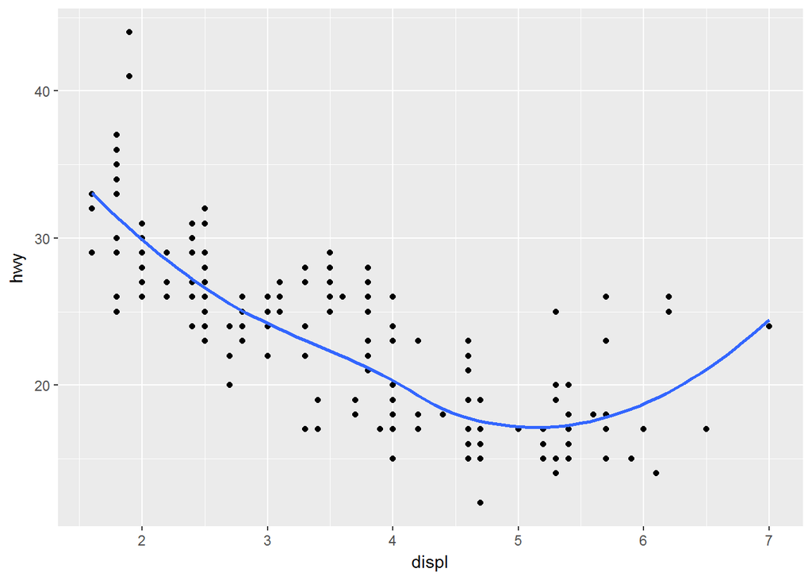

```r
# If you don't want the confidence bands:
p + geom_point() + geom_smooth(se=FALSE)
```

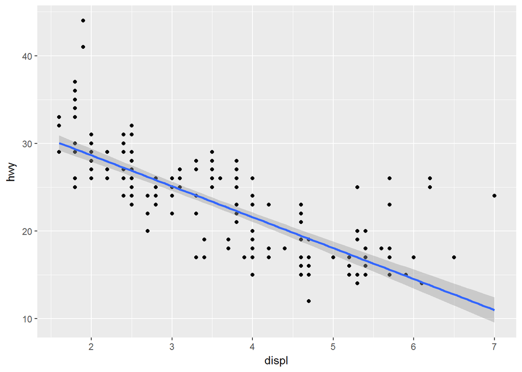

```r
# geom_smooth can do other kinds of regression, including linear:
p + geom_point() + geom_smooth(method = "lm")
```

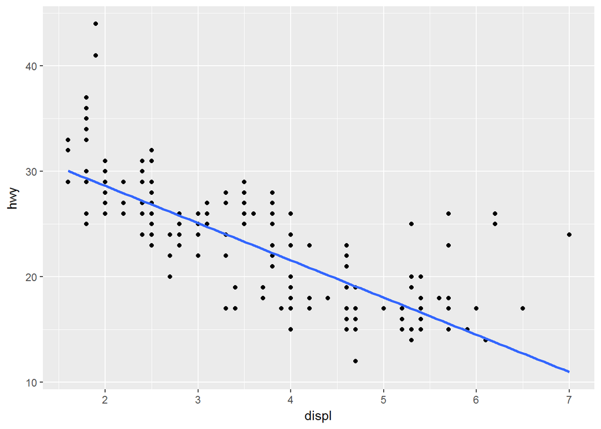

```r
p + geom_point() + geom_smooth(method = "lm", se=FALSE)
```

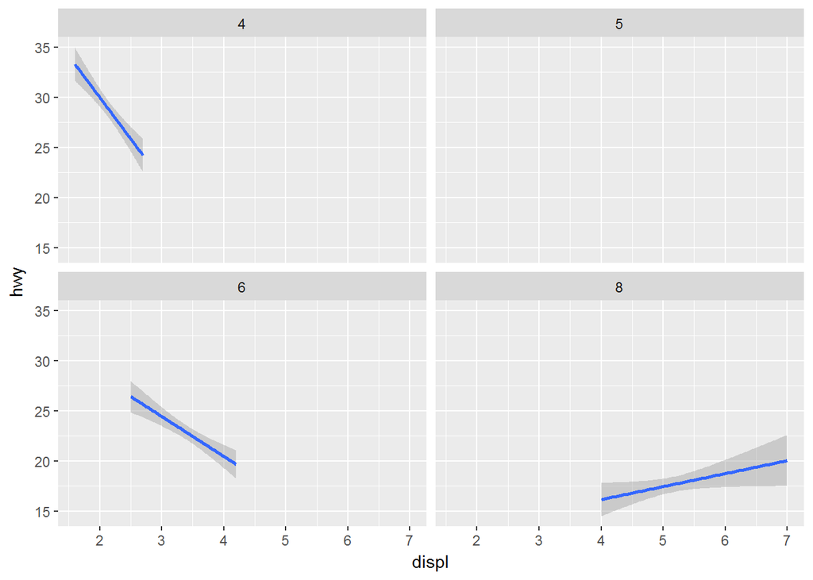

```r
# An example with facets:
p + facet_wrap(~cyl) + geom_smooth(method = "lm") #oops no points!
```

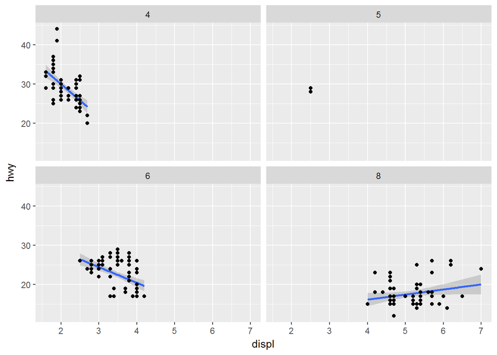

```r
p + facet_wrap(~cyl) + geom_smooth(method = "lm") + geom_point()
```